# Final Assignment: Natural Language Prediction

5/11/2018

## Next word

This app demonstrates the basic concepts of natural lanaguge prediction. It starts off with a rich corpora of news, blogs and twitter content from Swift Key. It ends with an app that predicts the **next word**, given any text input.

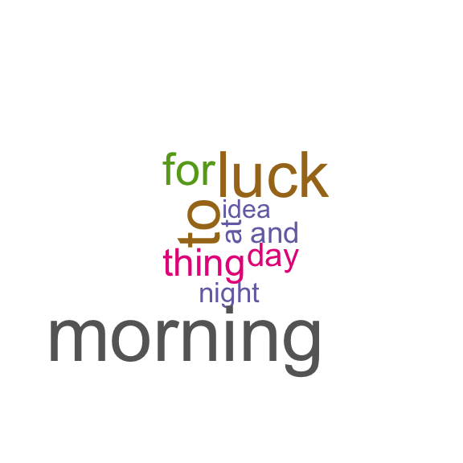

Hello there, good…

## The Data

Text data from blogs, news and twitter are not just text. They include characters and punctuation that can degrade natural language prediction. To create a **pure** database of language, the text data were processed as follows:

- all text was converted to lower case
- punctuation and numbers were removed
- special characters (html symbols, emoji characters, formatting) were removed
- the text was converted to plain text

## The Algorithm

The implemented algorithm makes use of look-up-tables (LUTs) constructed from the text data. This includes three key steps:

1. **LUT construction** - 5% of the dataset was sampled and converted to n-grams (maximum n=3) that were saved as LUTs, along with their frequencies of occurrence.
2. **Prediction** - a prediction algorithm was implemented based on these frequencies, using the Stupid backoff algorithm, with default behavior of sampling from unigram frequencies if an effective match could not be made.
3. The **LUTs** and **prediction** components were wrapped in an interactive shiny app!

## You try!

Try the app at this [shinyapps link](https://alenarto.shinyapps.io/shinyapp/)

For more information on natural language prediction:

- excellent tutorial from [stanford](https://cs.stanford.edu/people/eroberts/courses/soco/projects/2004-05/nlp/techniques_word.html)
- some basics on n-grams from [wikipedia](https://en.wikipedia.org/wiki/N-gram)